# NEON Data Analysis of Verrucomicrobiota and Niwot Ridge

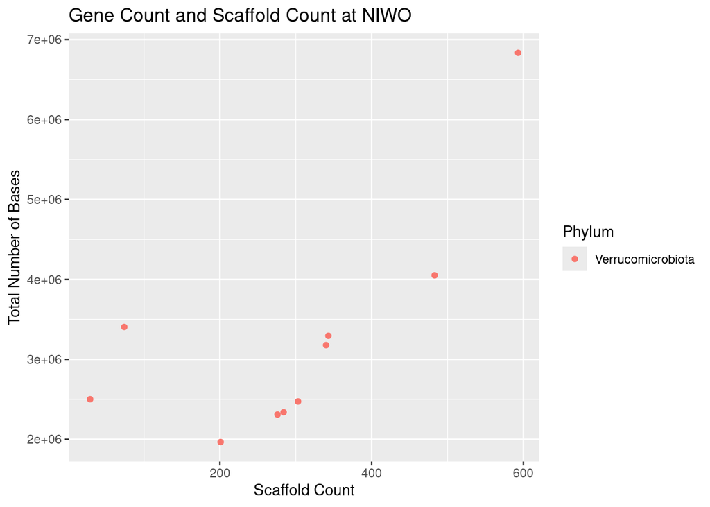

```r
NEON_data_NIWO %>%
  filter(Phylum == "Verrucomicrobiota") %>%
  ggplot(aes(x= `Scaffold Count`, y= `Total Number of Bases`, color = Phylum ))+
  geom_point()+
  labs(title = "Gene Count and Scaffold Count at NIWO")
```

### Verrucomicrobiota Scaffold Count and Total Number of Bases

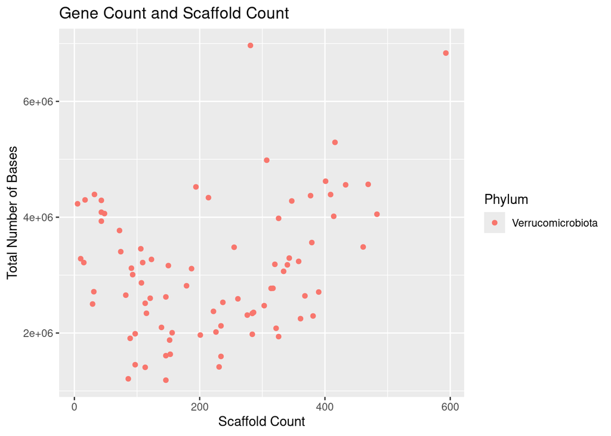

```r
NEON_data_Verruco %>%
  ggplot(aes(x= `Scaffold Count`, y= `Total Number of Bases`, color = Phylum ))+
  geom_point()+
  labs(title = "Gene Count and Scaffold Count")
```

### Niwot Ridge

#### Phyla at Niwot Ridge

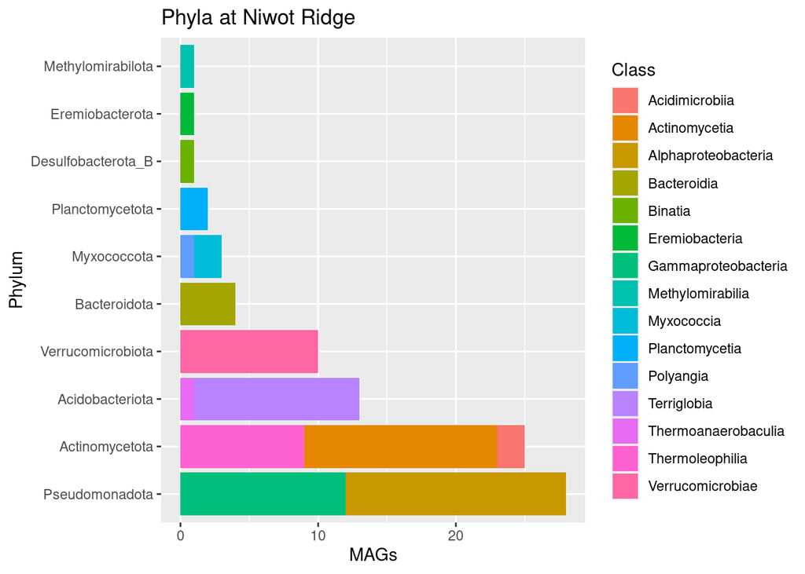

```r
NEON_data_NIWO %>%
  ggplot(aes(x = fct_infreq(Phylum), fill=Class))+
  geom_bar()+
  labs(title = "Phyla at Niwot Ridge", y = "MAGs", x= "Phylum", fill = "Class")+
  coord_flip()
```

#### Genome Size Distribution at Niwot Ridge boxplot

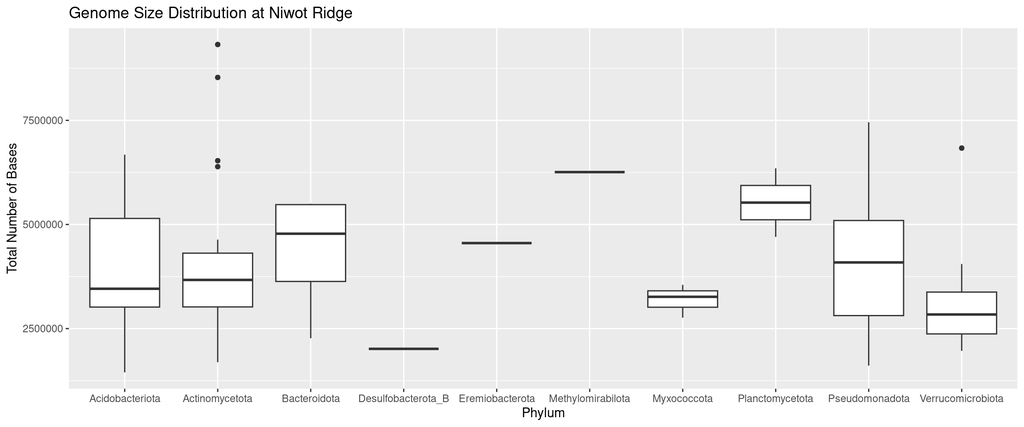

```r
NEON_data_NIWO %>%
  ggplot(aes(x= Phylum, y= `Total Number of Bases` ))+
  geom_boxplot()+
  labs(title = "Genome Size Distribution at Niwot Ridge")
```

#### Gene Count Distribution at Niwot Ridge

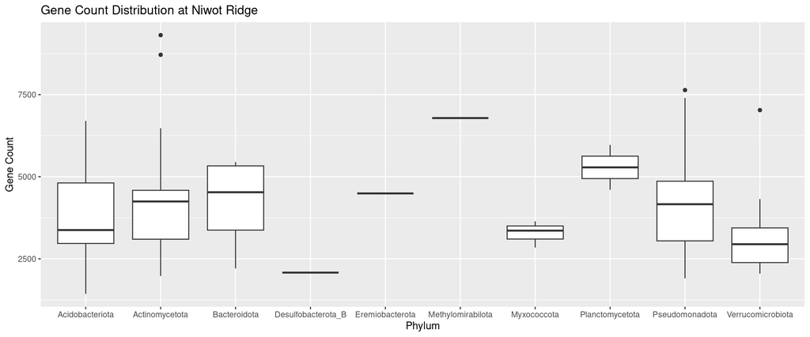

```r
NEON_data_NIWO %>%
  ggplot(aes(x= Phylum, y= `Gene Count`))+
  geom_boxplot()+
  labs(title = "Gene Count Distribution at Niwot Ridge")
```

#### tRNA Distribution at Niwot Ridge

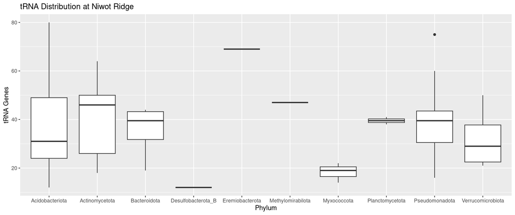

```r
NEON_data_NIWO %>%
  ggplot(aes(x= Phylum, y= `tRNA Genes` ))+
  geom_boxplot()+
  labs(title = "tRNA Distribution at Niwot Ridge")
```

#### Novel Bacteria at Niwot Ridge

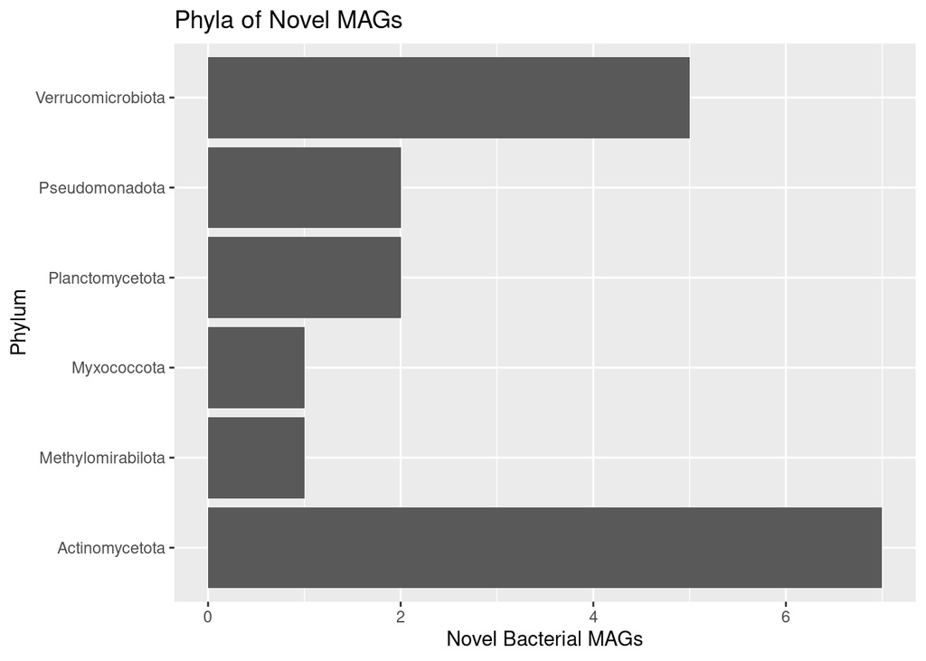

```r
NEON_data_NIWO %>%
  filter(is.na(Genus)) %>%
  ggplot(aes(x= Phylum))+
  geom_bar()+
  labs(title = "Phyla of Novel MAGs", y = "Novel Bacterial MAGs", x= "Phylum") +
  coord_flip()
```

#### nlcdclass of samples at Niwot Ridge

[figure not shown]

```r
ggplot(NEON_data_NIWO, aes(x = `nlcdClass`, y = `Sample Name`, color = Phylum)) +
  geom_point() +
  labs(title = "Relationship between nlcdclass and samples at NIWO",
       x = "Sample Name",
       y = "nlcdClass")
```

#### Histogram of Total Number of Bases at Niwot Ridge

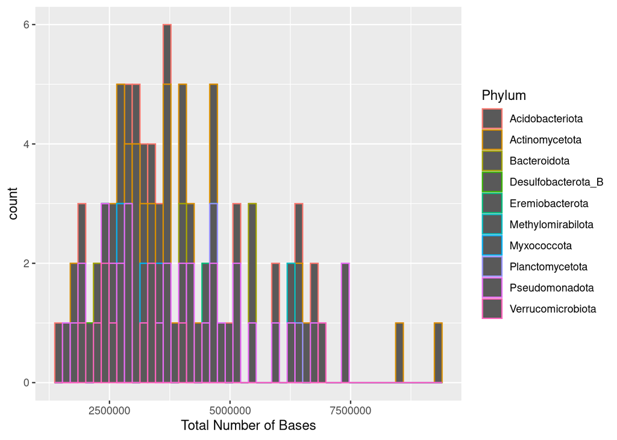

```r
NEON_data_NIWO %>%
ggplot(aes(x = `Total Number of Bases`, color = Phylum)) +
  geom_histogram(bins = 50)
```

#### Total Number of Bases and Bin quality at Niwot Ridge

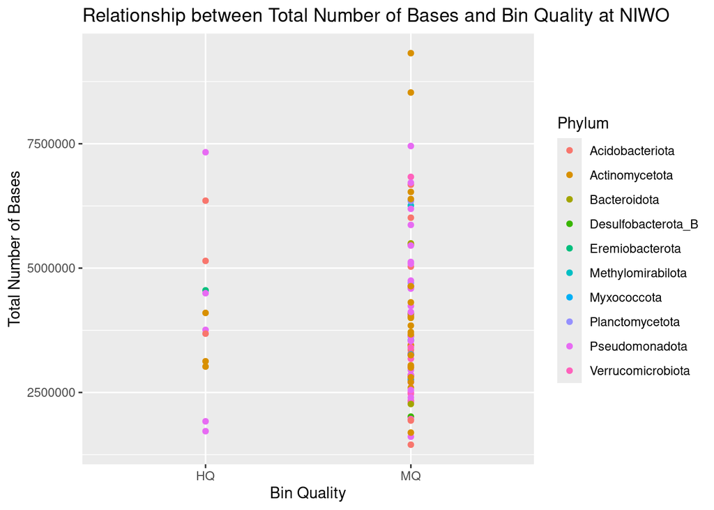

```r
NEON_data_NIWO %>%
  ggplot(aes(x= `Bin Quality`, y= `Total Number of Bases`, color = Phylum))+
  geom_point()+
  labs(title = "Relationship between Total Number of Bases and Bin Quality at NIWO", y = "Total Number of Bases", x= "Bin Quality")
```

### General NEON Properties

#### Total Number of Bases for all NEON samples

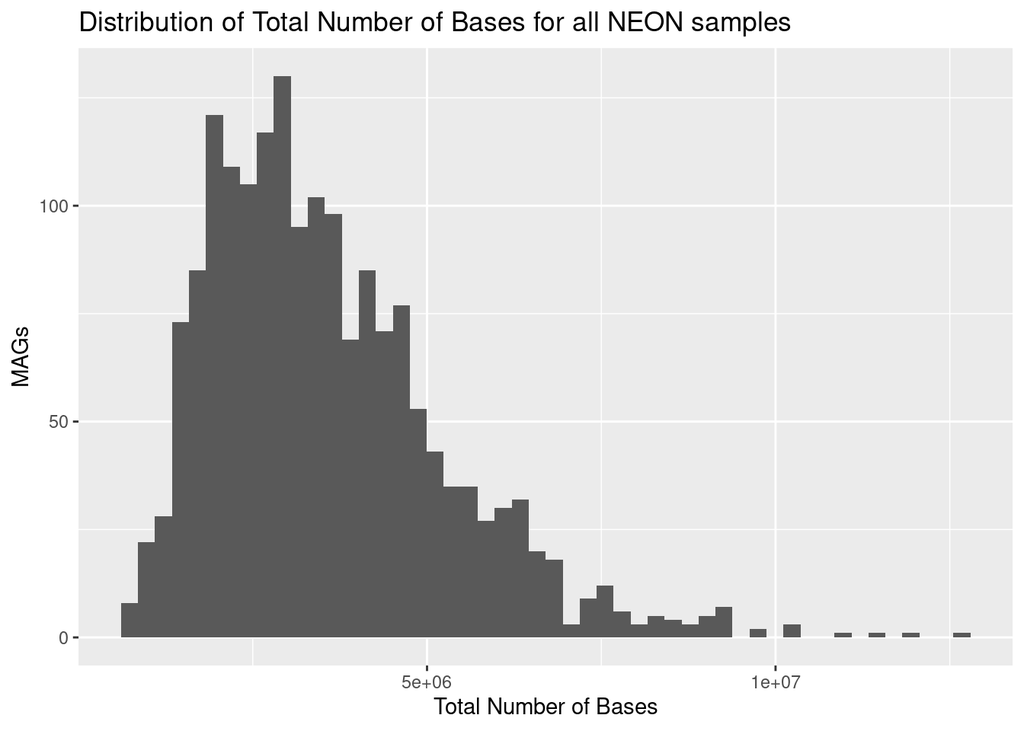

```r
NEON_data %>%
  ggplot(aes(x= `Total Number of Bases`))+
  geom_histogram(bins = 50)+
  labs(title="Distribution of Total Number of Bases for all NEON samples", y="MAGs")
```

#### Novel Bacteria per Site

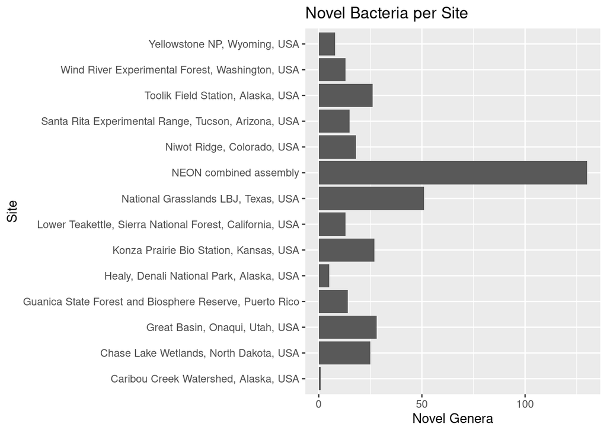

```r
NEON_data %>%
  filter(is.na(Genus)) %>%
ggplot(aes(x = Site.x))+
  geom_bar() +
  labs(title = "Novel Bacteria per Site", y = "Novel Genera", x= "Site")+
  coord_flip()
```

#### Phyla of Novel MAGs

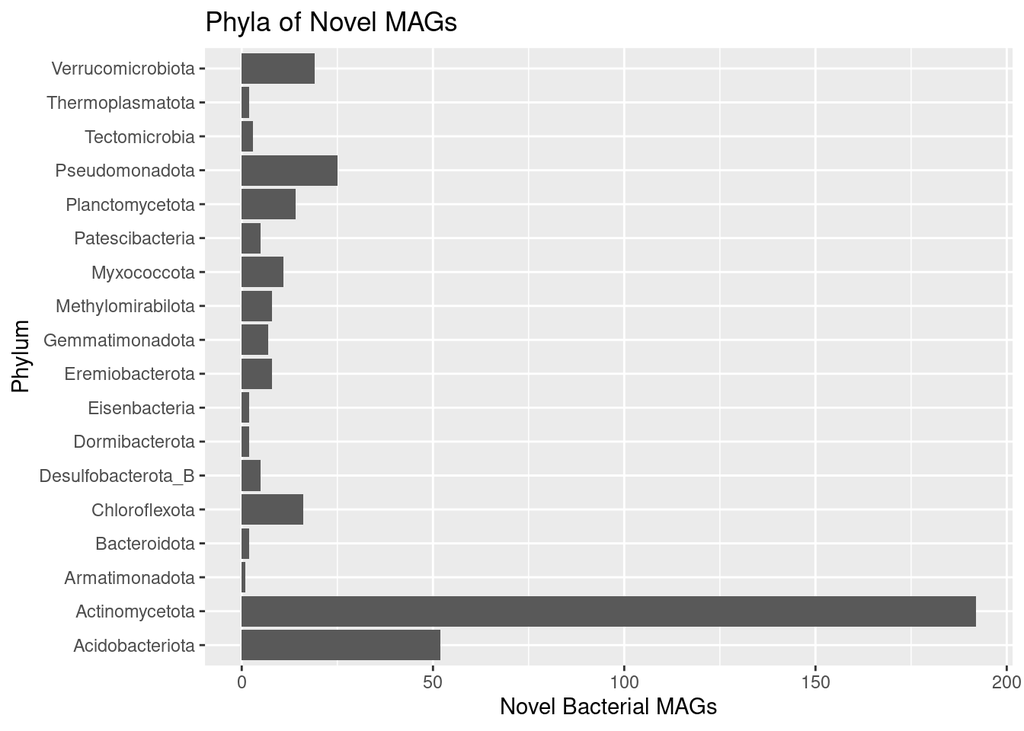

```r
NEON_data %>%
  filter(is.na(Genus)) %>%
  ggplot(aes(x= Phylum))+
  geom_bar()+
  labs(title = "Phyla of Novel MAGs", y = "Novel Bacterial MAGs", x= "Phylum") +
  coord_flip()
```

# Discussion

## Environmental Data

We found that, overall, Verrucomicrobiota is a phylum that is found under many different environmental conditions. There were wide spreads of distribution across soil temperature and pH, but the most common conditions were temperatures between 10 and 20 degrees celsius and pH values between 6 and 7. This observation mirrors that of the overall studied MAGs. Verrucomicrobiota were found in 6 different ecosystem subtypes, and these locations were well-distributed throughout their phylogeny. Interestingly, for soil nutrients Verrucomicrobiota tended to be at the high and low ends, but not the middle, of the spectra for both nitrogen and organic carbon amounts, but both of these observations may have been influenced by sample size. Finally, the phylum was found at a variety of different depths, but the most common by far was 0.10 meters (although this is also likely influenced by the types of sampling). Overall, this would imply that Verrucomicrobiota is able to adapt to many different environments, perhaps meaning that they could resist environmental changes.

We also expanded our study of environmental data into different sites, focusing on Niwot Ridge but also examining the other NEON sites due to a lack of data available for Niwot. We found correlations between soil temperature and elevation at Niwot Ridge but not for all sites, as well as a weak one between soil temperature and pH over all NEON sites. The different ecosystem subtypes had different average temperatures which was to be expected. Niwot Ridge was determined to be fully Terrestrial Soil, with a fairly even split between mineral and organic soil samples and a variety of elevations.

## Genome and Assembly Data

In addition to environmental factors we looked into the genomic properties of the Verrucomicrobiota included in this study. There was a clear relationship between genome size and gene count, which was to be expected. Genome size varied slightly between orders of Verrucomicrobiota, but dramatically between genera, with JAFAMB01 having the largest genomes. There was also variety in 16s rRNA counts and tRNA counts. Several novel species of Verrucomicrobiota were discovered, with most of them being of the order Chthoniobacterales For their assemblies, there was not a noticeable relationship between scaffold count, bin completeness, and genome size, and a majority of the samples were of medium bin quality.

At Niwot Ridge, like the total data set, there was a variety of genome sizes and phyla. The most common phylum was Pseudomonadota, and Verrucomicrobiota was the fourth most common type. Of novel bacteria, most were Actinomycetota with Verrucomicrobiota a close second.

Looking at the overall data, there was a wide distribution of genome sizes, but a large majority were less than 5 million bases. Novel bacteria were found at all the sites, but the most common place to find novel species was in the combined assemblies. Of these novel bacteria, most were of the phylum Actinomycetota, and Verrucomicrobiota had an intermediate number. These results suggest that sampling NEON sites, including Niwot Ridge, can provide a variety of information and can contribute new genera and species, which is both exciting and useful for scientific work.

## Project Limitations and Next Steps

This project was significantly limited by a lack of available data for both our phylum and, especially, for our site. For example, in our graph comparing soil temperature and pH at Niwot Ridge, there are only 6 points because very few environmental readings were done at our site. We also were unable to explore other factors that would have been of interest, such as chlorophyll concentration, algal bloom, and other soil nutrients such as sulfur (which is especially relevant to Verrucomicrobiota species). Future studies could investigate these factors as well as following environmental trends over time. All of this could increase our understanding of Verrucomicrobiota and other phyla’s roles in different ecosystems.

# Conclusion

The study provides a comprehensive insight into the different distributions, environmental preferences, and genomic characteristics of Verrucomicrobiota across various ecosystems and some of the studies having a focus on the Niwot Ridge. Studying the verrucomicrobiota showed a remarkable adaptability to diverse environmental conditions, pH levels, soil depths, and nutrient concentrations. It shows their resilience to different environments and conditions.

Furthermore, the NEON data from the different sites highlight the correlation between some of the factors that are important in ecological research like the soil pH, temperature, and elevation across other NEON sites, emphasizing the need for specific investigations. Analysis of the data showed patterns in genome size and gene count among others.

However, the study was constricted by the data limitations, particularly the lack of other environmental data for the specific site. The data could then be gathered for future research and investigated for the other environmental factors such as chlorophyll concentrations and in particular, their role in sulfur concentrations, advancing our knowledge of microbial communities and ecosystems functioning properly

# Bibliography

Bergmann, Gaddy T., Scott T. Bates, Kathryn G. Eilers, Christian L. Lauber, J. Gregory Caporaso, William A. Walters, Rob Knight, and Noah Fierer. 2011. “The Under-Recognized Dominance of Verrucomicrobia in Soil Bacterial Communities.” *Soil Biology & Biochemistry* 43 (7): 1450–55. https://doi.org/10.1016/j.soilbio.2011.03.012.

“Niwot Ridge NEON NSF NEON Open Data to Understand Our Ecosystems.” n.d. Accessed May 17, 2024. https://www.neonscience.org/field-sites/niwo.

Nixon, Sophie L., Rebecca A. Daly, Mikayla A. Borton, Lindsey M. Solden, Susan A. Welch, David R. Cole, Paula J. Mouser, Michael J. Wilkins, and Kelly C. Wrighton. 2019. “Genome-Resolved Metagenomics Extends the Environmental Distribution of the Verrucomicrobia Phylum to the Deep Terrestrial Subsurface.” *mSphere* 4 (6): e00613–19. https://doi.org/10.1128/mSphere.00613-19.

“Role of Soil Bacteria.” n.d. Accessed May 17, 2024. https://ohioline.osu.edu/factsheet/anr-36.

Ruan, Yang, Yakov Kuzyakov, Xiaoyu Liu, Xuhui Zhang, Qicheng Xu, Junjie Guo, Shiwei Guo, Qirong Shen, Yunfeng Yang, and Ning Ling. 2023. “Elevated Temperature and CO2 Strongly Affect the Growth Strategies of Soil Bacteria.” *Nature Communications* 14 (1): 391. https://doi.org/10.1038/s41467-023-36086-y.